# Questionnaire Report for Red snapper

(MERA version 5.4.3)

Brett van Poorten (brett.vanpoorten@gmail.com)

2019-11-26

# About this document

This is a prototype of an automatic report that documents how the user specified the operating model and their various justifications.

# Introduction

1. Describe the history and current status of the fishery, including fleets, sectors, vessel types and practices/gear by vessel type, landing ports, economics/markets, whether targeted/bycatch, other stocks caught in the fishery. “Red snapper have been harvested from the Gulf of Mexico (Gulf) since at least the 1840s(1). The fishery began in the northeastern Gulf, centered around Pensacola, Florida(1)(2). During the early development of the fishery, harvest was limited to vessels known as “smacks”(3) that fished close to port. When ice and trains became readily available to store and transport red snapper, vessels began to make longer voyages and landings increased(2).

Fishery scientists and fishermen first observed localized depletion of red snapper off Florida in the late 19th century(1)(4). Early catches were dominated by large fish, often averaging 10 pounds or more; but, as depletion occurred, the availability of fish near shore declined and vessels extended their trips farther from port to catch fish(1). Beginning in the late 1800s, vessels began harvesting red snapper from Campeche Bank off Mexico(5) and by the early 1900s U.S. commercial landings exceeded 7 million pounds, although few were from the Western Gulf(6). It was not until the 1930s and 1940s that fishing activity increased in the Western Gulf as rock ridges and snapper banks were discovered(7). Commercial landings fluctuated between 2 and 5 million pounds up until the 1950s as vessels shifted effort from U.S. waters to Campeche Bank in the early 1900s(6). After World War II there was a large increase in the size of the commercial fleet(7) and technological innovations, such as fathometers, reels, and wire fishing line opened up new fishing grounds(8) resulting in a large increase in landings in the western Gulf(6). During this period, the shrimp fishery also rapidly expanded. Markets increased for pink and brown shrimp as new fishing grounds were discovered and vessels began using double-rig trawls, which greatly increased the amount of shrimp that could be caught per unit of effort(9). The number of days spent shrimping more than doubled between the 1960s and 1990s. Because juvenile red snapper (age 0-1) are accidentally captured in shrimp trawls, the shrimp trawl fishery became a significant source of red snapper mortality. Prior to World War II, recreational fishing in the Gulf was fairly limited. But after the war, increased tourism along the Gulf coast coupled with the mass production of fiberglass boats and improvements in motor technology and navigational equipment led to increases in recreational fishing(11). This increased demand for recreational fishing opportunities spawned a large party boat fishery that primarily targeted red snapper(12). Annual recreational landings quickly grew from less than 500,000 pounds prior to 1950 to over 5 million pounds by the late 1990s(13). Today, recreational anglers account for more than half of the total Gulf red snapper landings and discard large amounts of red snapper at sea due to restrictions on harvest and retention." (https://sero.nmfs.noaa.gov/sustainable_fisheries/gulf_fisheries/red_snapper/overview/) The fishery is currently assessed at being overfished (B/B0=0.18) but not undergoing overfishing (F=0.052; F/MFMT=0.877) The fishery is composed of commercial (handline and longline) and recreational (including headboats and private/charter fleets) fisheries Although there is a large targeted fishery, juvenile snapper are also heavily caught as bycatch in the shrimp fishery There are other species caught as bycatch; gear modifications are regulated to minimize bycatch

2. Describe the stock’s ecosystem functions, dependencies, and habitat types. "Red snappers are considered reef fish, so it would be logical to assume that they eat smaller creatures from the reefs. Interestingly, most of their diet has been found to consist of creatures that live on mud bottoms, so red snappers get very little nutritional benefit from reefs. Fish are the number one item in their diet, with the most common ones being pipefish, snake eels, searobins, pinfish, striped anchovies, cusk eels, and pigfish.

Stomatopods (king shrimp or sea lice) are the second most important food item, followed by several species of crabs. Also eaten are tiny pinhead-size zooplankton and bottom worms. Shrimp make up only a very small portion of their diet.

Food habits change by season. Fish are always important, but crabs are the most common food item in spring and stomatopods are most important in the winter. A lot of stomatopods are also eaten in the summer, but almost none in the spring or fall. Diet also changes with fish size. As red snappers grow larger, they eat more fish. Also, the largest snappers, those 24 inches long and longer, eat far more stomatopods. Red snappers also have daily feeding patterns. One study showed that they had empty stomachs from 7:00 p.m. until 3:00 a.m. It seemed that the fish then began feeding heavily, reaching a peak at 4:00 a.m., but continued heavy feeding until 6:00 a.m. "(https://www.seagrantfish.lsu.edu/biological/snapper/redsnapper.htm)

3. Provide all relevant reference materials, such as assessments, research, and other analysis. Red Snapper Stock Assessment.pdf https://sero.nmfs.noaa.gov/sustainable_fisheries/gulf_fisheries/red_snapper/overview/ https://www.fisheries.noaa.gov/species/red-snapper http://safmc.net/regulations/regulations-by-species/red-snapper/ https://www.seagrantfish.lsu.edu/biological/snapper/redsnapper.htm

# Fishery Characteristics

## Longevity

| Answered |
| --- |
| Very short-lived (5 < maximum age < 7) |
| Short-lived (7 < maximum age < 10) |
| Moderate life span (10 < maximum age < 20) |
| Moderately long-lived (20 < maximum age < 40) |
| Long-lived (40 < maximum age < 80) |
| Very long-lived (80 < maximum age < 160) |

Justification

“The highest estimated age for red snapper to date was 57 years based on counting otolith rings, but this was based on a single fish and there is some uncertainty in that estimate. Noting that the oldest age that has been validated by bomb radiocarbon dating was 38 years old, the SEDAR 31 Panel adopted an intermediate value of 48 years for the maximum age (5 fish have been aged at 48 years old).” (Red Snapper Stock Assessment.pdf)

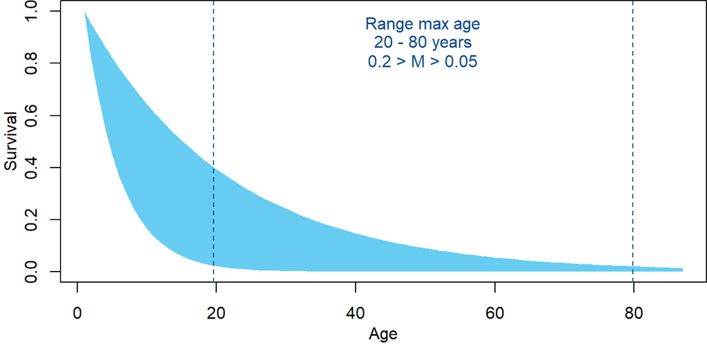

## Stock depletion

| Answered |
| --- |
| Crashed (D < 0.05) |
| Very depleted (0.05 < D < 0.1) |
| Depleted (0.1 < D < 0.15) |
| Moderately depleted (0.15 < D < 0.3) |
| Healthy (0.3 < D < 0.5) |
| Underexploited (0.5 < D) |

Justification

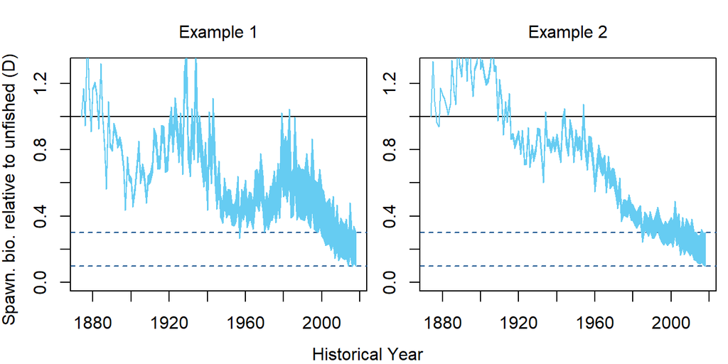

## Resilence

| Answered |
| --- |
| Not resilient (steepness < 0.3) |
| Low resilience (0.3 < steepness < 0.5) |
| Moderate resilence (0.5 < steepness < 0.7) |
| Resilient (0.7 < steepness < 0.9) |
| Very Resilient (0.9 < steepness) |

[output not shown]

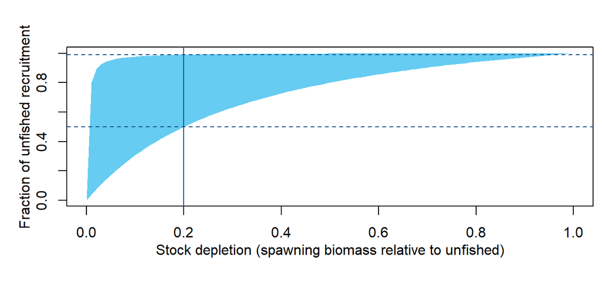

## Historical effort pattern

| Answered |
| --- |
| Stable |
| Two-phase |
| Boom-bust |
| Gradual increases |
| Stable, recent increases |
| Stable, recent declines |

| Justification |
| --- |
| Table 5.3: Red Snapper Stock Assessment.pdf |

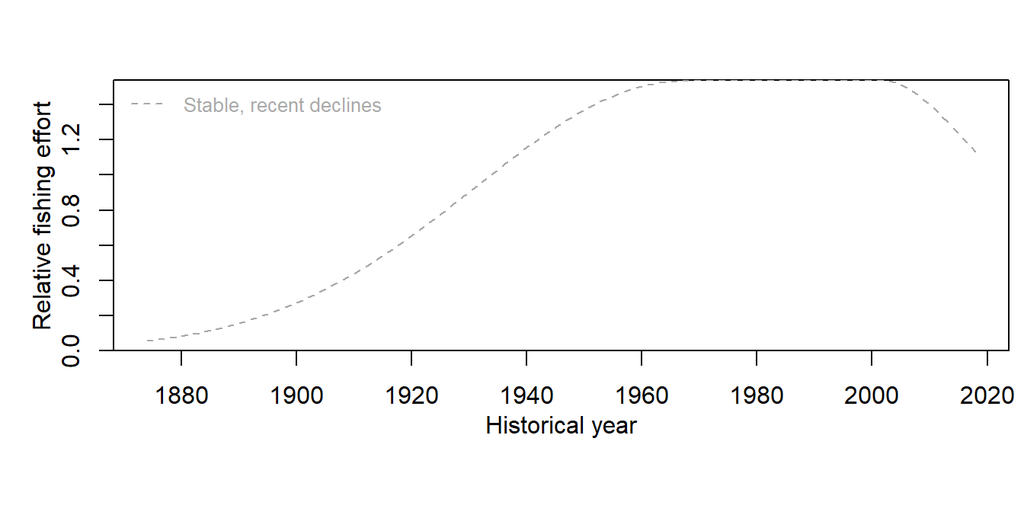

## Inter-annual variability in historical effort

| Answered |
| --- |
| Not variable (less than 20% inter-annual change (IAC)) |
| Variable (maximum IAC between 20% to 50%) |
| Highly variable (maximum IAC between 50% and 100%) |

| Justification |
| --- |
| Fishing effort is relatively stable from year to year (Table 5.3, Red Snapper Stock Assessment.pdf) |

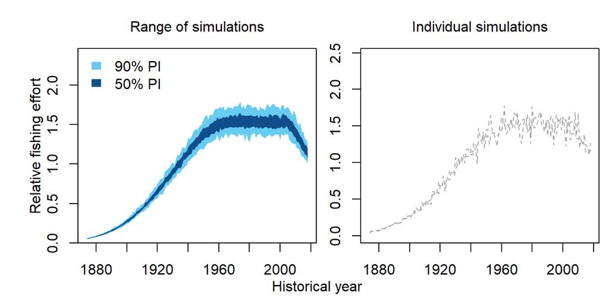

## Historical fishing efficiency changes

| Answered |
| --- |
| Declining by 2-3% pa (halves every 25-35 years) |
| Declining by 1-2% pa (halves every 35-70 years) |
| Stable -1% to 1% pa (may halve/double every 70 years) |
| Increasing by 1-2% pa (doubles every 35-70 years) |
| Increasing by 2-3% pa (doubles every 25-35 years) |

[output not shown]

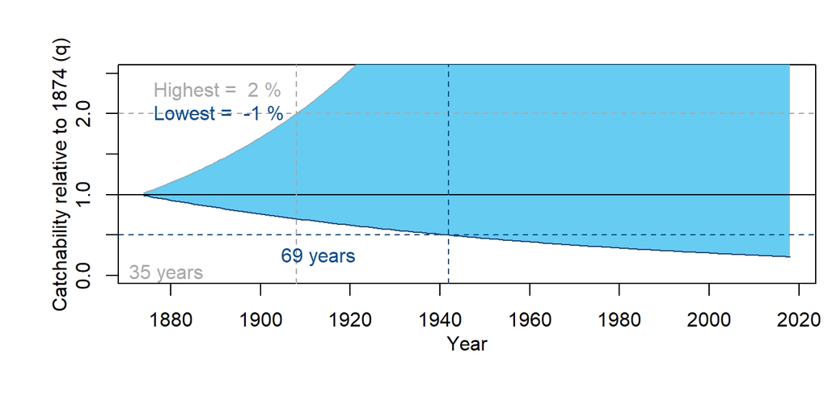

## Future fishing efficiency changes

| Answered |
| --- |
| Declining by 2-3% pa (halves every 25-35 years) |
| Declining by 1-2% pa (halves every 35-70 years) |
| Stable -1% to 1% pa (may halve/double every 70 years) |
| Increasing by 1-2% pa (doubles every 35-70 years) |
| Increasing by 2-3% pa (doubles every 25-35 years) |

| Justification |
| --- |
| There are no dramatic changes in efficiency predicted |

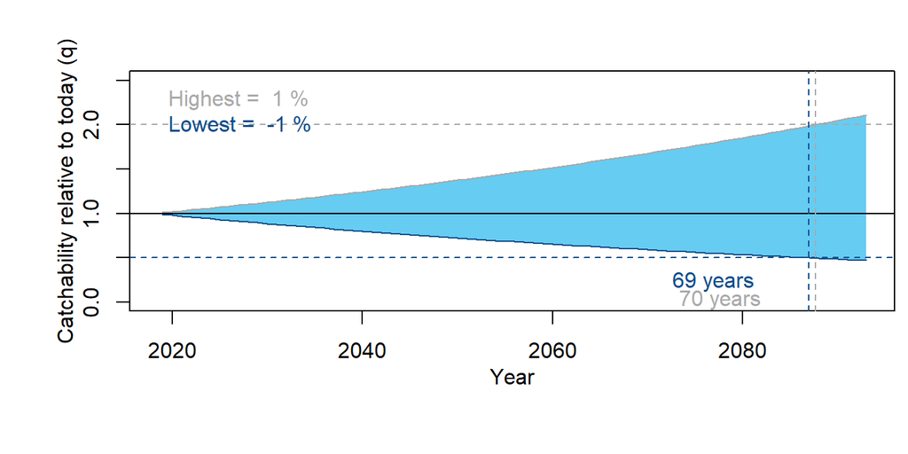

## Length at maturity

| Answered |
| --- |
| Very small (0.4 < LM < 0.5) |
| Small (0.5 < LM < 0.6) |
| Moderate (0.6 < LM < 0.7) |
| Moderate to large (0.7 < LM < 0.8) |
| Large (0.8 < LM < 0.9) |

[output not shown]

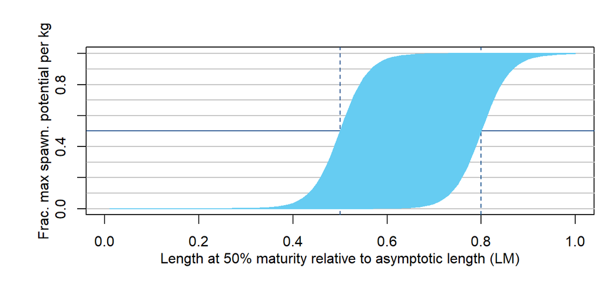

## Selectivity of small fish

| Answered |
| --- |
| Very small (0.1 < S < 0.2) |
| Small (0.2 < S < 0.4) |
| Half asymptotic length (0.4 < S < 0.6) |
| Large (0.6 < S < 0.8) |
| Very large (0.8 < S < 0.9) |

[output not shown]

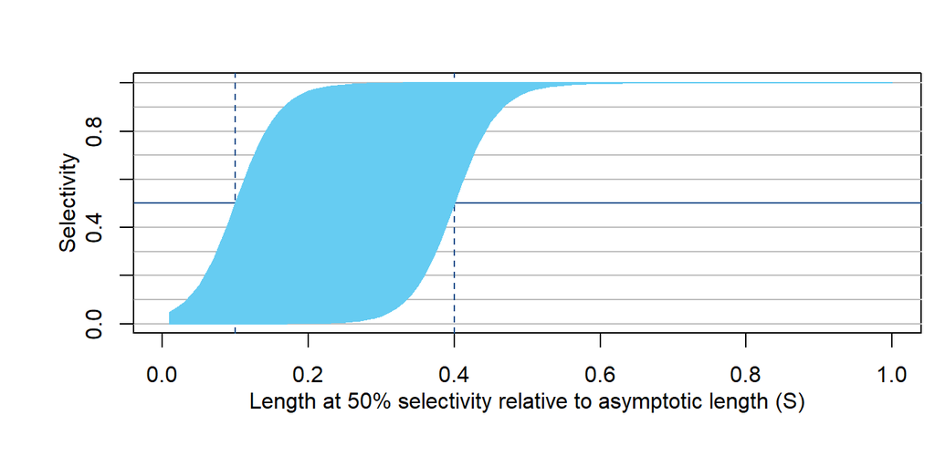

## Selectivity of large fish

| Answered |
| --- |
| Asymptotic selectivity (SL = 1) |
| Declining selectivity with length (0.75 < SL < 1) |
| Dome-shaped selectivity (0.25 < SL < 0.75) |
| Strong dome-shaped selectivity (SL < 0.25) |

| Justification |
| --- |
| All gears avoid the very largest fish (Figure 4.9 of Red Snapper Stock Assessment.pdf), but some are very dome-shaped. |

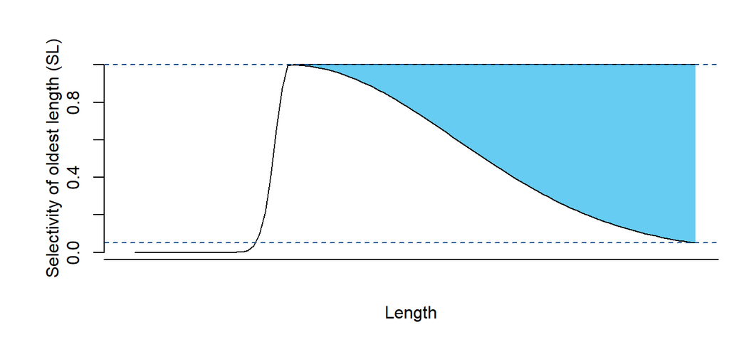

## Discard rate

| Answered |
| --- |
| Low (DR < 1%) |
| Low - moderate (1% < DR < 10%) |
| Moderate (10% < DR < 30%) |
| Moderate - high (30% < DR < 50%) |
| High (50% < DR < 70%) |

| Justification |
| --- |
| The commercial fleets have low to moderate discarding rates, but the recreational fishery has very high discarding rates. |

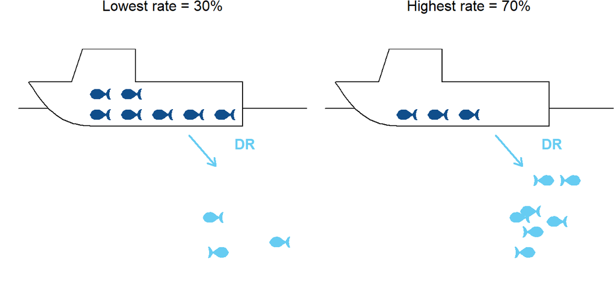

## Post-release mortality rate

| Answered |
| --- |
| Low (PRM < 5%) |
| Low - moderate (5% < PRM < 25%) |
| Moderate (25% < PRM < 50%) |
| Moderate - high (50% < PRM < 75%) |
| High (75% < PRM < 95%) |
| Almost all die (95% < PRM < 100%) |

Justification

Discard mortality has been experimentally estimated. Venting of released fish was manditory from 2008-2013, which resulted in reduced release mortality; rates of release mortality range between 0.118 (vented fish released from recreational fishery) to 0.91 (non-vented released mortality released from the longline fleet). (see Release Mortality.pdf from Red Snapper Stock Assessment.pdf)

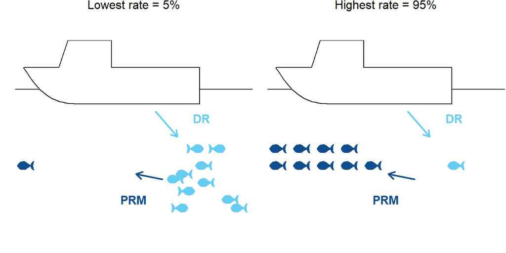

## Recruitment variability

| Answered |
| --- |
| Very low (less than 20% inter-annual changes (IAC)) |
| Low (max IAC of between 20% and 60%) |
| Moderate (max IAC of between 60% and 120%) |
| High (max IAC of between 120% and 180%) |
| Very high (max IAC greater than 180%) |

| Justification |
| --- |
| Estimated recruitment is very stable over time (see Table 4.1 of Red Snapper Stock Assessment.pdf) |

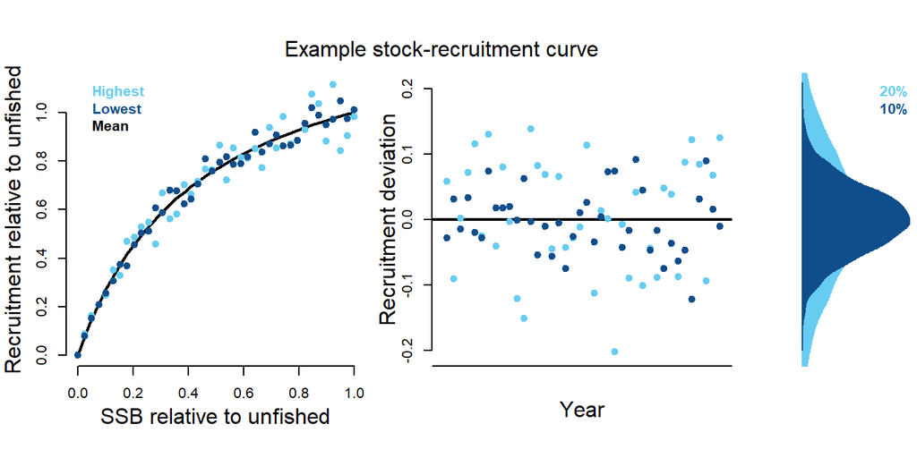

## Size of an existing MPA

| Answered |
| --- |
| None |
| Small (A < 5%) |
| Small-moderate (5% < A < 10%) |
| Moderate (10% < A < 20%) |
| Large (20% < A < 30%) |
| Very large (30% < A < 40%) |
| Huge (40% < A < 50%) |

| Justification |
| --- |
| There are many areas closed to fishing, but they are a small area of the total habitat (see Tables 2.2.1 in Red Snapper Stock Assessment.pdf) |

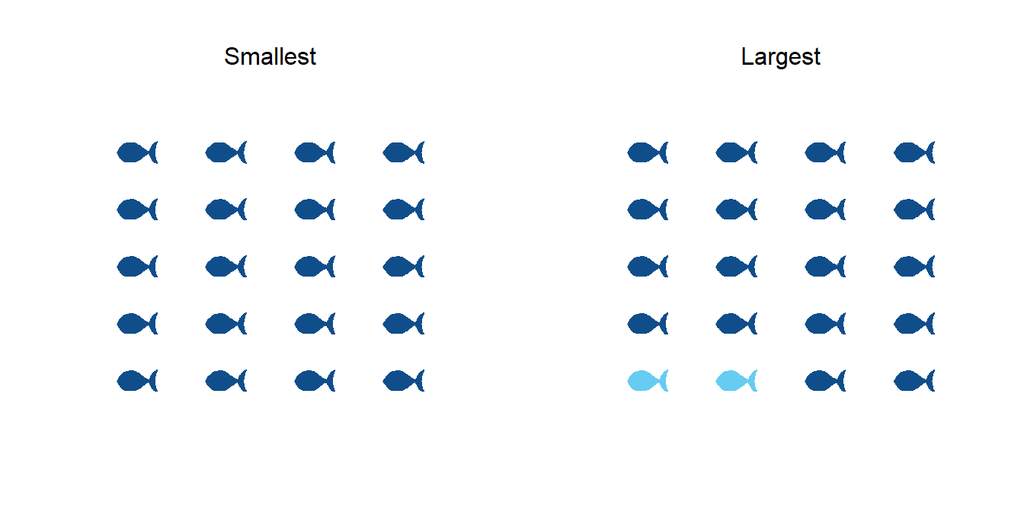

## Spatial mixing (movement) in/out of existing MPA

| Answered |
| --- |
| Very low (P < 1%) |
| Low (1% < P < 5%) |
| Moderate (5% < P < 10%) |
| High (10% < P < 20%) |
| Fully mixed |

| Justification |
| --- |
| mean movement over time is < 30km (Patterson et al. 2001) |

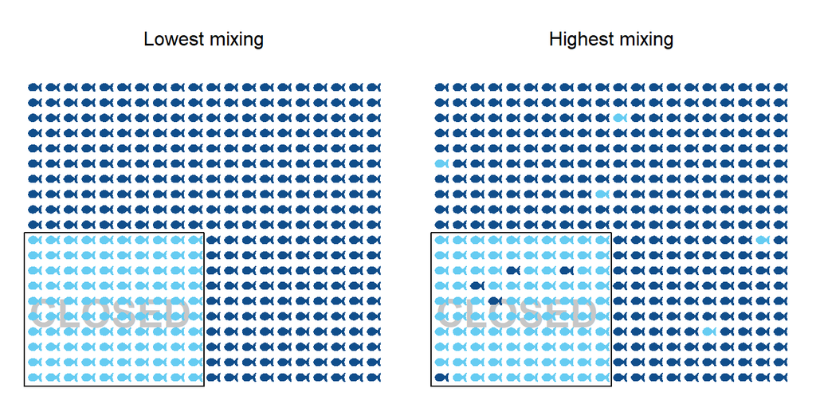

## Size of a future potential MPA

| Answered |
| --- |
| None |
| Small (A < 5%) |
| Small-moderate (5% < A < 10%) |
| Moderate (10% < A < 20%) |
| Large (20% < A < 30%) |
| Very large (30% < A < 40%) |
| Huge (40% < A < 50%) |

| Justification |
| --- |
| No new spatial areas are being considered |

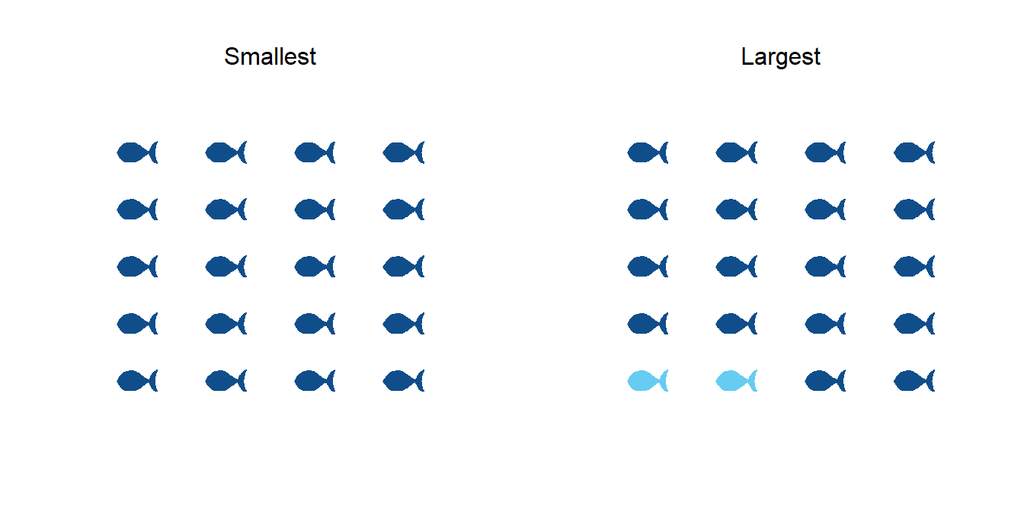

## Spatial mixing (movement) in/out of future potential MPA

| Answered |
| --- |
| Very low (P < 1%) |
| Low (1% < P < 5%) |
| Moderate (5% < P < 10%) |
| High (10% < P < 20%) |
| Fully mixed |

| Justification |
| --- |
| Mean movement distance of tagged fish is <30km (Patterson et al. 2001) |

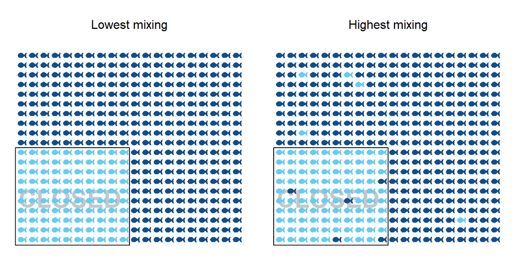

## Initial stock depletion

| Answered |
| --- |
| Very low (0.1 < D1 < 0.15) |
| Low (0.15 < D1 < 0.3) |
| Moderate (0.3 < D < 0.5) |
| High (0.5 < D1) |
| Asymptotic unfished levels (D1 = 1) |

| Justification |
| --- |
| Initial depletion is estimated as 67% (Red Snapper Stock Assessment.pdf) |

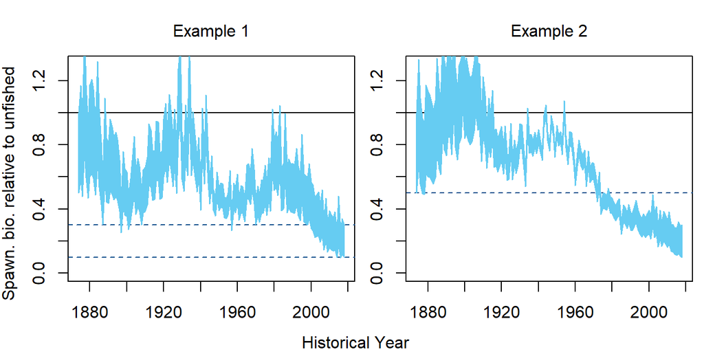

# Management Characteristics

## Types of fishery management that are possible

| Answered |
| --- |
| TAC (Total Allowable Catch): a catch limit |
| TAE (Total Allowable Effort): an effort limit |
| Size limit |
| Time-area closures (a marine reserve) |

Justification

1. Describe what, if any, current management measures are used to constrain catch/effort.  
(all info here from http://safmc.net/regulations/regulations-by-species/red-snapper/)  
Recreational fishery: limited fishing season; one-fish daily bag limit; no size limit; annual catch limits imposed for all reef species  
Commercial fishery: limited fishing season, which may be closed if catch limit is reached; daily trip limits; no size limit  
2. Describe historical management measures, if any.  
Managed under the Snapper Grouper Fishery Management Plan. Initially included size limits, gear restrictions and provision for Special Management Zones. In 1998, in an attempt to limit effort, anyone wishing to enter the commercial fishery had to buy two transferrable vessel permits  
3. Describe main strengths and weaknesses of current monitoring and enforcement capacity.  
Data collection in the recreational fishery is somewhat coordinated across states; states work together to ensure data collection is consistent and efficient. MRIP also collects information across states and federal waters.  
Commercial fishers must submit logbooks and ~10% logbooks recording discards; Observers on ~1% of reef fish boats; portside monitoring; 100% shrimp boat statistics; 1% shrimp boat observer coverage; accumulated landings system (100% coverage)  
Strengths: high coverage overall;  
Weaknesses: low accuracy of data: low creel coverage; low observer coverage, slow turnaround of data to inform management (see Monitoring Gulf of Mexico Fishery.pdf)  
4. Describe and reference any legal/policy requirements for management, monitoring and enforcement.

## TAC offset: consistent overages/underages

| Answered |
| --- |
| Large underages (40% - 70% of recommended) |
| Underages (70% - 90% of recommended) |
| Slight underages (90% - 100% of recommended) |
| Taken exactly (95% - 105% of recommended) |
| Slight overages (100% - 110% of recommended) |
| Overages (110% - 150% of recommended) |
| Large overages (150% - 200% of recommended) |

[output not shown]

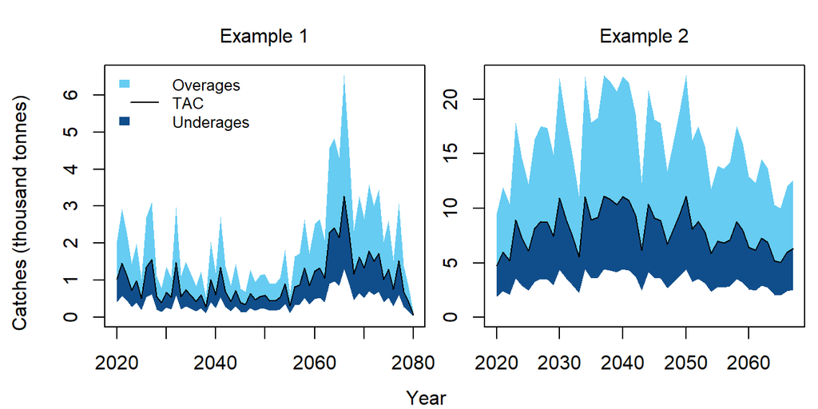

## TAC implementation variability

| Answered |
| --- |
| Constant (V < 1%) |
| Not variable (1% < V < 5%) |
| Low variability (5% < V < 10%) |
| Variable (10% < V < 20%) |
| Highly variable (20% < V < 40%) |

| Justification |
| --- |
| Quota quite variable (see Commercial quota.png; Recreational quota.png) |

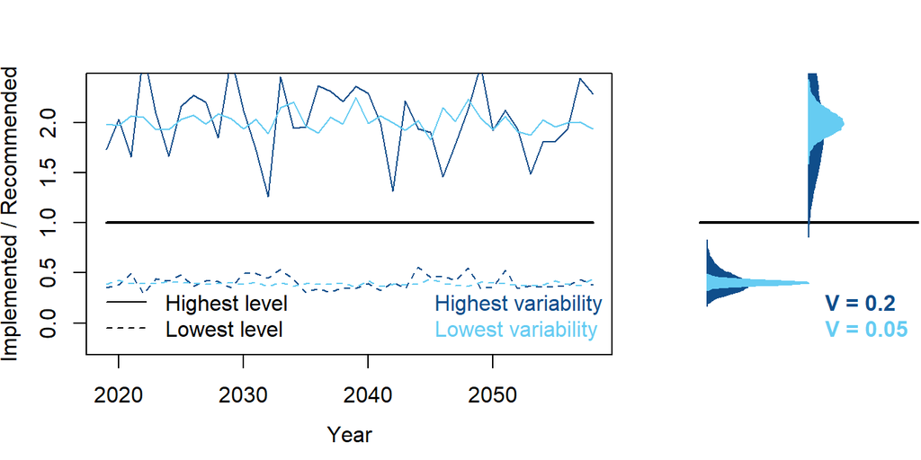

## TAE offset: consistent overages/underages

| Answered |
| --- |
| Large underages (40% - 70% of recommended) |
| Underages (70% - 90% of recommended) |
| Slight underages (90% - 100% of recommended) |
| Taken exactly (95% - 105% of recommended) |
| Slight overages (100% - 110% of recommended) |
| Overages (110% - 150% of recommended) |
| Large overages (150% - 200% of recommended) |

| Justification |
| --- |
| No TAE, apart from number of days open |

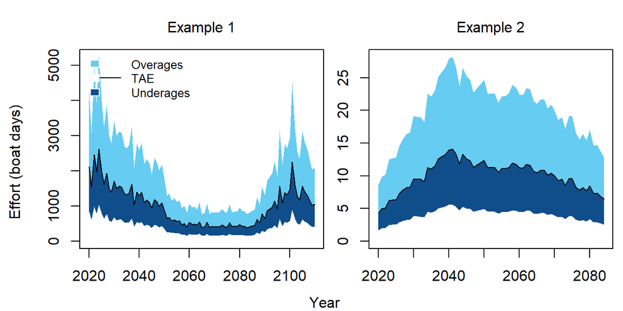

## TAE implementation variability

| Answered |
| --- |
| Constant (V < 1%) |
| Not variable (1% < V < 5%) |
| Low variability (5% < V < 10%) |
| Variable (10% < V < 20%) |
| Highly variable (20% < V < 40%) |

| Justification |
| --- |
| No TAE |

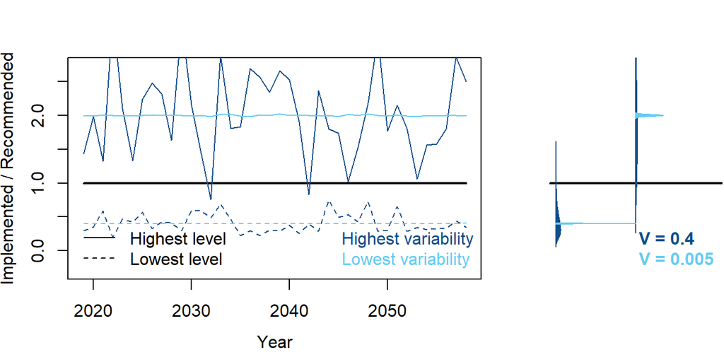

## Size limit offset: consistent overages/underages

| Answered |
| --- |
| Much smaller (40% - 70% of recommended) |
| Smaller (70% - 90% of recommended) |
| Slightly smaller (90% - 100% of recommended) |
| Taken exactly (95% - 105% of recommended) |
| Slightly larger (100% - 110% of recommended) |
| Larger (110% - 150% of recommended) |
| Much larger (150% - 200% of recommended) |

[output not shown]

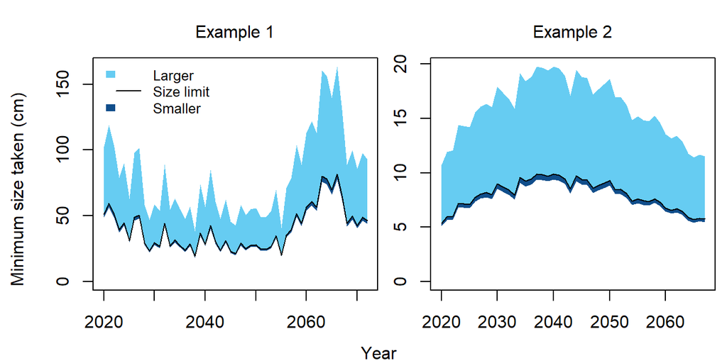

## Size limit implementation variability

| Answered |
| --- |
| Constant (V < 1%) |
| Not variable (1% < V < 5%) |
| Low variability (5% < V < 10%) |
| Variable (10% < V < 20%) |
| Highly variable (20% < V < 40%) |

| Justification |
| --- |
| Size limit variation is shown in size limit.png - has changed 5 times and only by 1-2 inches each time. |

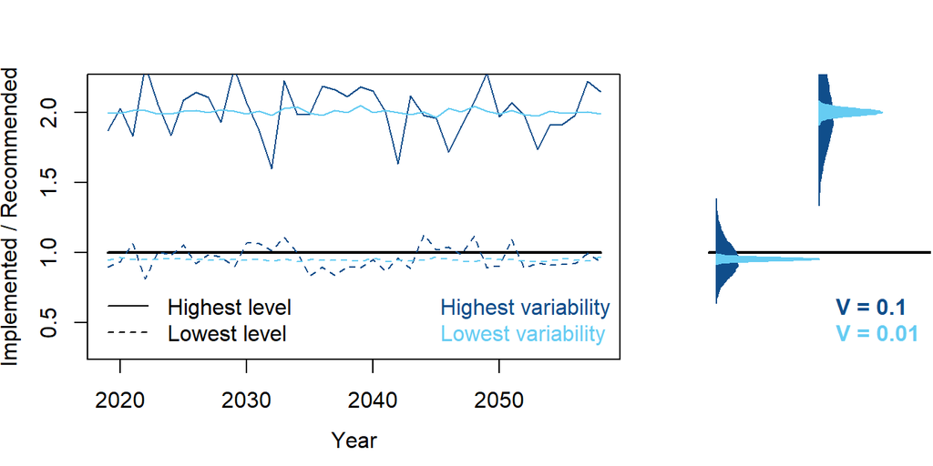

# Data Characteristics

## Available data types

| Answered |
| --- |
| Historical annual catches (from unfished) |
| Recent annual catches (at least 5 recent years) |
| Historical relative abundance index (from unfished) |
| Recent relative abundance index (at least 5 recent years) |
| Fishing effort |
| Size composition (length samples) |
| Age composition (age samples) |
| Growth (growth parameters) |
| Absolute biomass survey |

Justification

1. Provide the time series (specify years, if possible) that exist for catch, effort, and CPUE/abundance indices.  
Commercial landings since 1872  
Commercial age structure since 1991  
Commercial discards since 1990  
Commercial fishery-dependent indices since 1981  
Recreational landings since 1950  
Recreational age-structure since 1991  
Recreational deadbeat discards since 1990  
Shrimp bycatch since 1972  
Shrimp effort since 1946  
Fishery-independent indices since 1972  
2. Describe how these data collected (e.g., log books, dealer reporting, observers).  
Fishery-independent:  
“Southeast Area Monitoring and Assessment Program (SEAMAP), a collaborative effort between federal, state and university programs, designed to collect, manage and distribute fishery independent data throughout the region: a trawl survey, a video survey on natural structure, and a larval survey. The fourth survey is conducted using bottom longlines deployed away from structure, and the fifth is a combination of ROV surveys. The methodologies used to standardize and incorporate these data into the assessment are identical to those employed during SEDAR 31 and therefore are only briefly reviewed below.” (Red Snapper Stock Assessment.pdf)  
Fishery landings are collected from port sampling. “Size and frequency distributions were developed from observations of maximum total length recorded in the Trip Interview Program (TIP). … Age frequency distributions were constructed from readings of otolith samples recorded in the same data bases. However, it was observed that the length frequency distributions of the red snapper age samples differed from the length frequency distributions of the larger set of red snapper length samples, particularly prior to 2000, suggesting the age samples were not representative in the earlier years. Accordingly, the age frequency distributions were reweighted by the length frequency distributions as done in SEDAR 31 (Table 2.6).” (Red Snapper Stock Assessment.pdf)  
Discards: “Data available for the calculation of red snapper discards from the commercial fishery during the years prior to Individual Fishing Quotas (IFQs) were limited to fisher-reported discard rates through the discard logbook program and fishing effort through the coastal logbook program. Complete years of observer reported data (2007-2016) coincide with management through IFQs. Commercial fishers report significant changes in fisher behavior under IFQ management; therefore, use of observer reported discard rates to calculate discards prior to 2007 would be inappropriate as discard rates prior to IFQs were likely different than discard rates under IFQs. Commercial discard estimates were not updated for the years prior to 2007. Methods for calculating commercial discards for the years prior to 2007 are included in SEDAR (2015).” (Red Snapper Stock Assessment.pdf)  
Recreational: “Estimates of the catch of these species come from a combination of results from four surveys: (1) the Marine Recreational Information Program (MRIP), formerly the Marine Recreational Fishery Statistics Survey (MRFSS), conducted by NOAA Fisheries (NMFS); (2) the Texas Marine Sport-Harvest Monitoring Program by the Texas Parks and Wildlife Department (TPWD); and (3) the Southeast Region Headboat Survey (SRHS) conducted by NMFS, Southeast Fisheries Science Center, Beaufort, NC; and (4) the Louisiana Creel Fish Survey (LA Creel).” (Red Snapper Stock Assessment.pdf)  
Shrimp bycatch: “The primary data on CPUE in the shrimp fishery came from a series of shrimp observer programs, which began in 1972 and extend to the current shrimp observer program. Additional CPUE data were obtained from the SEAMAP groundfish survey.” (Red Snapper Stock Assessment.pdf)  
3. Describe what types of sampling programs and methodologies exist for data collection, including the time-series of available sampling data and quality.  
above  
4. Describe all sources of uncertainty in the status, biology, life history and data sources of the fishery. Include links to documentation, reports.  
Recruitment compensation is unknown - set to 0.99. All other data are at least available, though discards prior to the implementation of ITQs in 2007 is unknown and has been corrected. All this is described in Red Snapper Stock Assessment.pdf. Additional thoughts in further monitoring (for future years) are described in Monitoring Gulf of Mexico Fishery.pdf

## Catch reporting bias

| Answered |
| --- |
| Strong under-reporting (30% - 50%) |
| Under-reporting (10% - 30%) |
| Slight under-reporting (0% - 10%) |
| Reported accurately (+/- 5%) |
| Slight over-reporting (less than 10%) |

Justification

Each state has mechanisms to get reporting by anglers, but it is voluntary: (e.g. “to make sure that Texas gets its share of red snapper – report your red snapper landings.”)  
“Data for quota management and stock assessment is collected through various programs, including Dealer Reports (DRs), Fishing Logbooks (FLs), observers, port sampling, trip interviews and vessel monitoring systems (VMS). Appendix III provides an inventory and characterization of monitoring and data collection programs currently operating in the GOM. For the most part, these programs are not coordinated or integrated and have varying degrees of success at collecting the required information. Information from DRs, FLs, and observers are used to calculate total fishery mortality by species against the stated quotas. Data from DRs, FLs, observed trips, port sampling and trip interviews are used in assessing the health of the stocks. VMS is used to monitor compliance with various fishing rules and regulations (i.e. fishing in closed areas).  
Under the Quota Monitoring System (QMS), Dealer Reports collect landed catch weight information on a species basis. Not all dealers are required to report and compliance by those who are required is 90 to 95 percent. Dealer Report data only has to be submitted every two weeks. For the red snapper IFQ fishery, DRs are required for all landings, submitted electronically, and provide data in a timely manner. Fishing Logbooks, which do not include estimates of at-sea releases, are mandatory for all Reef Fish permit vessels and must be mailed to NMFS within seven days after the end of a fishing trip. NMFS monitors vessel reporting compliance on a monthly basis. Fifty percent of logbooks are received more than two weeks after the end of fishing trips.” (Monitoring Gulf of Mexico Fishery.pdf)  
No information on reporting accuracy could be found. It is likely that there is some underreporting, particularly from the recreational fishery, which is coordinated across multiple agencies. While MRIP does a stratified random phone survey of residents, this is one of four sources of recreational data. Adjustments to data are made to try to account for bias.  
“The primary recreational modes of fishing for Gulf of Mexico red snapper are private, charter, and headboat vessels. Estimates of the catch of these species come from a combination of results from four surveys: (1) the Marine Recreational Information Program (MRIP), formerly the Marine Recreational Fishery Statistics Survey (MRFSS), conducted by NOAA Fisheries (NMFS); (2) the Texas Marine Sport-Harvest Monitoring Program by the Texas Parks and Wildlife Department (TPWD); and (3) the Southeast Region Headboat Survey (SRHS) conducted by NMFS, Southeast Fisheries Science Center, Beaufort, NC; and (4) the Louisiana Creel Fish Survey (LA Creel). The MRIP, TPWD, and LA Creel surveys are sampling-based, while the SRHS strives to be a census of headboats using logbooks. The four surveys together provide estimates of catch in numbers, estimates of effort, length and weight samples, and catch- effort observations for shore-based and boat fishing. Length samples were also obtained from the Fisheries Information Network, Trip Interview Program and observer programs operating in Florida, Alabama, and Louisiana.” (Red Snapper Stock Assessment.pdf)

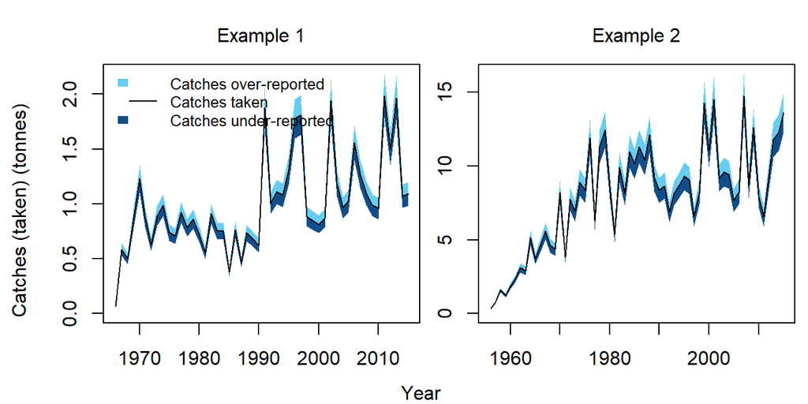